# Construccion de mapas de cobertura de la tierra usando el algoritmo Random Forest

J Camilo Fagua and Patrick Jantz

Diciembre 2022

## **1. OBJETIVOS**

1. Entender el flujo de trabajo necesario para la creacion de mapas empleando el algoritmo de aprendizaje Random Forest.
2. Aprender una metodologia para seleccionar las variables importantes en un modelo Random Forest.
3. Aprender una metodologia para ajustar los parametros de un modelo Random Forest.
4. Comprender como se calcula la exactitud tematica o error de un modelo.
5. Comprender como se calcula la exactitud tematica o error de un modelo espacial o mapa.

## **2. INTRODUCCION**

R es un lenguaje y un entorno para la manipulacion, el calculo y la visualizacion grafica de datos que incluye datos geoespaciales, como lo son los datos de sensores remotos. R es extremadamente poderoso y se usa ampliamente en investigacion academica y en sectores comerciales. Los usuarios de R deben escribir comandos en lenguaje R (un lenguaje de programacion basado en el lenguaje S) para ejecutar cualquier tarea. Una de las mayores ventajas de R, es que los usuarios pueden crear un script para proporcionar registros reproducibles de sus analisis. Esto significa que otros investigadores conocedores del tema especifico, pueden realizar los mismos analisis utilizando nuevos datos con algunas modificaciones al script (Lansley and Cheshire 2016, R Core Team 2021). En este tutorial se describe el desarrollo de un script que hace modelacion espacial de sensores remotos, para generar mapas de coberturas de tierra en un area de estudio en Colombia. Este script explica una ruta de trabajo con el algoritmo Random Forest, el cual tiende a generar errores mas bajos que otros algoritmos de aprendizaje.

El campo de investigacion en sensores remotos o teledeteccion es la adquisicion de informacion sobre un objeto sin hacer contacto fisico con el objeto. Los datos provenientes de sensores remotos que se utilizan para estudiar la superficie terrestre, registran ondas del espectro electromagnetico que las entidades terrestres reflejan (sensores pasivos) o envian ondas electromagneticas especificas y registran su rebote (sensores activos). Estos valores de las ondas del espectro electromagnetico se toman como variables predictoras para generar mapas sobre la cobertura de la tierra. La mayor parte de los datos provenientes de sensores remotos (imagenes satelitales de sensores multiespectrales, hiperespectrales y SAR) esta empaquetada en formatos raster (como son: .Img, .grd, .asc, .sdat, .rst,. tif, .nc, .envi, .bil, etc.). Un raster se puede interpretar como una matriz matematica, donde cada cuadricula (o pixel) representa el valor que un sensor registro en un area especifica de la superficie terrestre. Estos raster tienen cuatro propiedades que definen su capacidad para clasificar la cobertura de la tierra o para identificar objetos especificos:

1. Resolucion espacial del sensor. Esta es una medida del area mas pequena en la superficie de la Tierra, sobre la cual el sensor puede realizar una medicion independiente (es decir, el tamano del pixel). La resolucion espacial define el tamano del pixel del resultado de una modelacion de coberturas de la tierra.
2. Resolucion espectral. Se refiere a la capacidad de un sensor para definir intervalos de longitud de onda del espectro electromagnetico, que son reflejados por la superficie de la Tierra. La resolucion espectral define las variables (las bandas de un raster) que se utilizaran para la modelacion de coberturas de la tierra.
3. Resolucion radiometrica. Esta resolucion especifica que tanto se pueden percibir las diferencias dentro de cada banda de la imagen. La resolucion radiometrica se mide a traves del numero de bits (numeros binarios) o el numero maximo de niveles de valor de gris por banda. Un 8 bit indica que el sensor tiene 256 valores de gris por banda (por ejemplo, satelite Landsat-7). Una representacion de 16 bits significa que, en teoria, cada banda tiene 65.536 valores de gris (por ejemplo, Landsat-8). Mas bits significa que se puede almacenar mas informacion por banda en cada pixel. La resolucion radiometrica define los valores de las variables (bandas) en la modelacion de coberturas de la tierra.
4. Resolucion temporal. Se refiere a la frecuencia con que un sensor especifico registra informacion (imagenes) de un area en la superficie de la Tierra. La resolucion temporal define la fecha de la modelacion de coberturas de la tierra.

Nosotros, los usuarios de imagenes rasterizadas, hacemos ensayos con estas cuatro propiedades para clasificar y modelar grandes areas de la superficie de la Tierra. En este tutorial vamos a clasificar dos tipos de imagenes: 1) una imagen Sentinel-1 (sensor activo SAR) y una 2) Sentinel-2 (sensor pasivo multiespectral). Estas imagenes correspondientes a una ventana de observacion llamada Guane-Kalypso, la cual esta localiza en la region del Magdalena medio entre los departamentos de Bolivar, Santander y Antioquia (Figura 1).

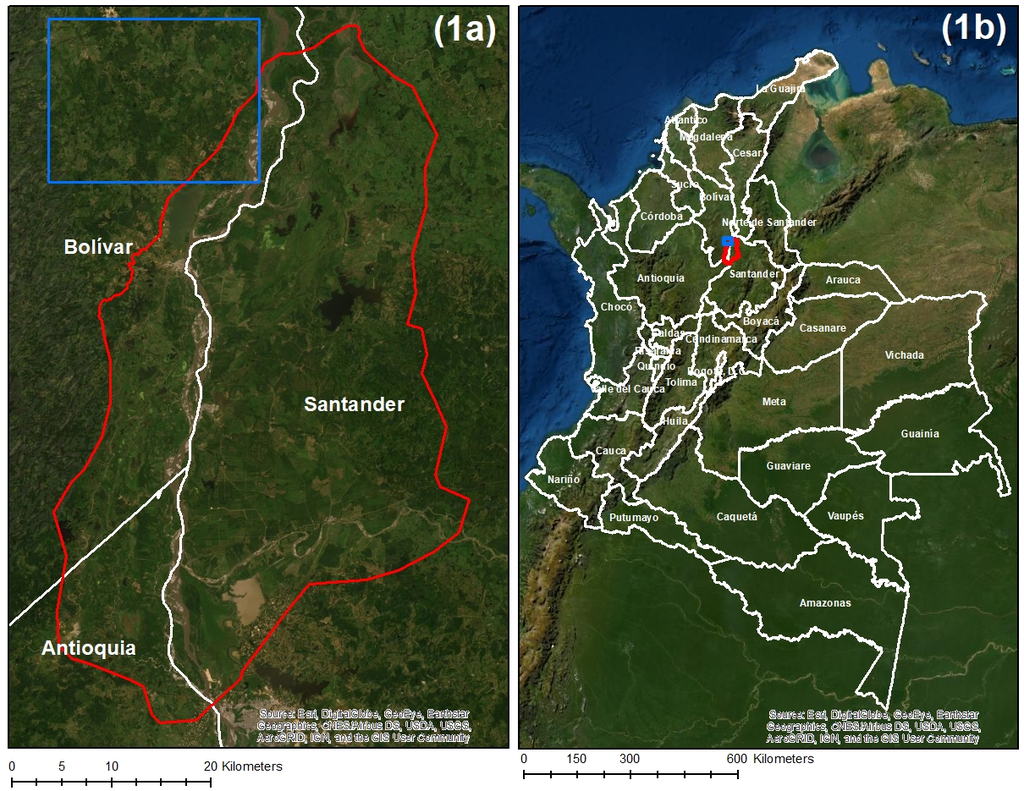

**Figura 1**. Area de estudio. Ventana de observacion Guane-Kalypso en rojo (1a). Zona de interpretacion visual (1b).

## **3. VARIABLES RESPUESTA Y PREDICTORAS**

En la modelacion de coberturas de la tierra la variable respuesta es categorica y hace referencia al tipo de coberturas de la tierra. Para este ejercicio se establecieron 11 categorias de cobertura de tierra: 1) Vegetacion arborea, 2) Vegetacion arbustiva, 3) Vegetacion herbacea, 4) Humedales, 5) Pastos, 6) Cultivos anuales, 7) Plantacion de palma joven, 8) Plantacion de palma madura, 9) Urbano - infraestructura, 10) Suelo sin vegetacion, y 11) Cuerpo de agua. El Anexo 1 es un documento (Leyenda ecologica.pdf) que muestra un catalogo visual de estas coberturas. La variable respuesta, cobertura de la tierra, sera modelada espacialmente usando 19 variables predictoras proveniente de los sensores Sentinel-1 (10 m pixel) y Sentinel-2 (10-20 m pixel). Cada variable predictora (coeficiente de retrodispersion, banda, o indice) es la media temporal y se calculo con todas las imagenes disponibles para el ano 2020 en el programa Google Earth Engine (TABLA 1).

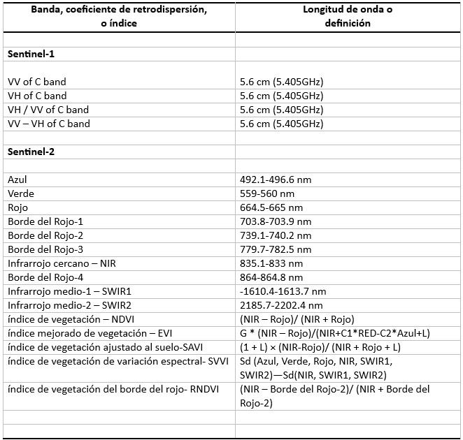

**TABLA 1**. Lista de variables SAR (Sentinel-1) y multiespectrales (Sentinel-2) que se emplearon como variables predictoras. Para cada coeficiente de retrodispersion, banda, o indice se calculo una media temporal con todas las imagenes disponibles para el ano 2020.

Para empezar, vamos a cargar las librerias randomForest, caret, Boruta, raster, ranger, Metrics, e irr. Si no las tienes instaladas, por favor, debes instalarlas.

```r
#install.packages("randomForest")
#install.packages("caret")
#install.packages("Boruta")
#install.packages("raster")
#install.packages("ranger")
#install.packages("Metrics")
#install.packages("irr")

library(randomForest)
library(Boruta)
library(caret)
library(raster)
library(ranger)
library(Metrics)
library(irr)
```

Ahora vamos a abrir una tabla donde tenemos relacionadas la variable respuesta (tipo de cobertura) y las variables predictoras (las variables Sentinel-1 y Sentinel-2 anteriormente descritas). Esta tabla corresponde a la interpretacion visual realizada en la zona de interpretacion de la ventana Guane-Kalypso (Cuadrado azul de la Figura 1b). Cada hilera de la tabla corresponde a una parcela (pixel de 10 metros correspondiente a los pixeles Sentinel) identificada como alguna de las 11 coberturas de tierra por interpretes expertos. Para garantizar alta confiabilidad para la clasificacion, en esta tabla solo se incluyeron parcelas con dos condiciones: 1) Parcelas donde el interprete tuvo una seguridad total de la identificacion visual y 2) Parcelas donde el total de la cobertura de la parcela de 10m corresponde a uno de los 11 tipos de cobertura.

En los archivos adjuntos de este tutorial se encuentran dos archivos .csv con las interpretaciones: 1) El archivo original de la interpretacion (TABLA_PARA_MODELAR.csv), el cual tiene 248,453 hileras o interpretaciones. 2) Un archivo reducido de la interpretacion (TABLA_PARA_MODELAR_REDUCIDA_DOS.csv), el cual tiene 2456 hileras o interpretaciones, separadas al menos 20 metros y seleccionadas azarosamente del archivo original. Las coberturas mas representadas en la interpretacion original fueron reducidas a 300, mientras que las interpretaciones menos representadas en el archivo original (Vegetacion arbustiva y Urbano - infraestructura) mantuvieron las interpretaciones del archivo original. La Figura 2 muestra que la seleccion azarosa garantiza que los datos reducidos tengan la misma distribucion espacial que los datos originales.

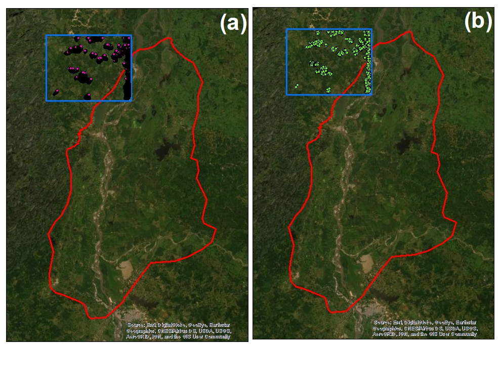

**FIGURA 2**. Distribucion de las parcelas de interpretacion. (1a). Total de datos (248.453 parcelas). (1b). Datos fueron reducidos azarosamente (2456 parcelas).

NOTA: En este tutorial trabajaremos con los datos reducidos (2456 datos) debido a las limitaciones de tiempo y memoria de los computadores, sin embargo, para hacer que la clasificacion sea lo mas precisa posible, se debe emplear la mayor cantidad de datos separados por 20m (248.453 datos).

```r
#setwd("")# Para fijar el directorio.
TABLA = read.csv("TABLA_PARA_MODELAR_REDUCIDA_DOS.csv", header = TRUE, sep = ",")
#TABLA = read.csv("TABLA_PARA_MODELAR.csv", header = TRUE, sep = ",")
names(TABLA)
```

```
##  [1] "LeyEco"     "Long"       "Lat"        "VV"         "VH"
##  [6] "VHdivVV"    "VVminVH"    "BLUE"       "GREEN"      "RED"
## [11] "RED_EDGE_1" "RED_EDGE_2" "RED_EDGE_3" "NIR"        "RED_EDGE_4"
## [16] "SWIR_1"     "SWIR_2"     "NDVI"       "EVI"        "SAVI"
## [21] "SVVI"       "RNDVI"
```

```r
dim(TABLA)
```

```
## [1] 2456   22
```

```r
head(TABLA)
```

```
##   LeyEco      Long      Lat   VV  VH VHdivVV VVminVH BLUE GREEN RED RED_EDGE_1
## 1      1 -73.85701 7.625664 1041 261    3048     780  370   580 379       1016
## 2      1 -73.98933 7.662045 1901 500    3085    1400  370   555 408        902
## 3      1 -73.88989 7.654949 2587 657    3257    1930  320   598 307        994
## 4      1 -73.97236 7.694564 2029 493    2663    1536  312   564 301        961
## 5      1 -73.98556 7.666178 1882 485    2943    1397  364   569 331        821
## 6      1 -73.98610 7.670849 2256 543    2822    1713  338   530 316        847
##   RED_EDGE_2 RED_EDGE_3  NIR RED_EDGE_4 SWIR_1 SWIR_2 NDVI  EVI SAVI SVVI RNDVI
## 1       2375       2789 2553       3149   1998   1019 7367 4494 1807  198   325
## 2       2172       2646 2691       2944   1986   1017 7303 4614 1869  176  1056
## 3       3181       3913 4064       4214   1991    888 8546 6904 2644   19  1212
## 4       2850       3558 3386       3942   1853    780 8359 5991 2361   39   862
## 5       2489       3224 3213       3551   1760    765 8126 5772 2242   27  1283
## 6       2446       3084 3143       3448   1791    781 8151 5639 2218   52  1254
```

La funcion table() nos permite ver la distribucion de los datos segun el tipo de cobertura, los cuales estan identificados con un numero, tal como fue descrito anteriormente. 1) Vegetacion arborea, 2) Vegetacion arbustiva, 3) Vegetacion herbacea, 4) Humedales, 5) Pastos, 6) Cultivos anuales, 7) Plantacion de palma joven, 8) Plantacion de palma madura, 9) Urbano - infraestructura, 10) Suelo sin vegetacion, y 11) Cuerpo de agua.

```r
table(TABLA$LeyEco)
```

```
##
##   1   2   3   4   5   7   8   9  10  11
## 300  30 300 300 300 300 300  26 300 300
```

Ahora hacemos una nueva tabla, TABLA_1, para limipiar NAs y para convertir la variable LeyEco (tipo de cobertura) de numerica a factor.

```r
TABLA_1 = TABLA[complete.cases(TABLA), ]# para eliminar hileras con datos NA.
dim(TABLA_1)
```

```
## [1] 2456   22
```

```r
head(TABLA_1)
```

```
##   LeyEco      Long      Lat   VV  VH VHdivVV VVminVH BLUE GREEN RED RED_EDGE_1
## 1      1 -73.85701 7.625664 1041 261    3048     780  370   580 379       1016
## 2      1 -73.98933 7.662045 1901 500    3085    1400  370   555 408        902
## 3      1 -73.88989 7.654949 2587 657    3257    1930  320   598 307        994
## 4      1 -73.97236 7.694564 2029 493    2663    1536  312   564 301        961
## 5      1 -73.98556 7.666178 1882 485    2943    1397  364   569 331        821
## 6      1 -73.98610 7.670849 2256 543    2822    1713  338   530 316        847
##   RED_EDGE_2 RED_EDGE_3  NIR RED_EDGE_4 SWIR_1 SWIR_2 NDVI  EVI SAVI SVVI RNDVI
## 1       2375       2789 2553       3149   1998   1019 7367 4494 1807  198   325
## 2       2172       2646 2691       2944   1986   1017 7303 4614 1869  176  1056
## 3       3181       3913 4064       4214   1991    888 8546 6904 2644   19  1212
## 4       2850       3558 3386       3942   1853    780 8359 5991 2361   39   862
## 5       2489       3224 3213       3551   1760    765 8126 5772 2242   27  1283
## 6       2446       3084 3143       3448   1791    781 8151 5639 2218   52  1254
```

```r
#
TABLA_1$LeyEco = as.factor(TABLA_1$LeyEco)
str(TABLA_1)
```

```
## 'data.frame':    2456 obs. of  22 variables:
##  $ LeyEco    : Factor w/ 10 levels "1","2","3","4",..: 1 1 1 1 1 1 1 1 1 1 ...
##  $ Long      : num  -73.9 -74 -73.9 -74 -74 ...
##  $ Lat       : num  7.63 7.66 7.65 7.69 7.67 ...
##  $ VV        : int  1041 1901 2587 2029 1882 2256 2880 2560 2231 2544 ...
##  $ VH        : int  261 500 657 493 485 543 673 607 439 589 ...
##  $ VHdivVV   : int  3048 3085 3257 2663 2943 2822 2764 2680 2513 2936 ...
##  $ VVminVH   : int  780 1400 1930 1536 1397 1713 2206 1952 1791 1955 ...
##  $ BLUE      : int  370 370 320 312 364 338 290 316 309 336 ...
##  $ GREEN     : int  580 555 598 564 569 530 450 490 496 609 ...
##  $ RED       : int  379 408 307 301 331 316 307 289 279 321 ...
##  $ RED_EDGE_1: int  1016 902 994 961 821 847 812 823 805 978 ...
##  $ RED_EDGE_2: int  2375 2172 3181 2850 2489 2446 2309 2964 2602 2968 ...
##  $ RED_EDGE_3: int  2789 2646 3913 3558 3224 3084 2912 3727 3360 3704 ...
##  $ NIR       : int  2553 2691 4064 3386 3213 3143 2563 3496 3464 3733 ...
##  $ RED_EDGE_4: int  3149 2944 4214 3942 3551 3448 3271 4071 3728 3965 ...
##  $ SWIR_1    : int  1998 1986 1991 1853 1760 1791 1759 1912 1700 1838 ...
##  $ SWIR_2    : int  1019 1017 888 780 765 781 782 814 697 852 ...
##  $ NDVI      : int  7367 7303 8546 8359 8126 8151 7782 8433 8506 8362 ...
##  $ EVI       : int  4494 4614 6904 5991 5772 5639 4589 6208 6198 6456 ...
##  $ SAVI      : int  1807 1869 2644 2361 2242 2218 1893 2419 2422 2497 ...
##  $ SVVI      : int  198 176 19 39 27 52 119 56 -6 14 ...
##  $ RNDVI     : int  325 1056 1212 862 1283 1254 477 812 1414 1136 ...
```

## **3. SELECCION DE VARIABLES**

Un primer paso en la modelacion es descartar predictores que no tiene efecto en la modelacion que se realizara (una clasificacion Random Forest). Para esto utilizaremos el algoritmo Boruta (Shi et al. 2019), el cual compara la importancia de los predictores con predictores denominados predictores sombra (copias ficticias de los predictores reales que se generan por permutaciones aleatorias de los valores de los predictores reales) en numerosas clasificaciones Random Forest (100 en nuestro caso que es el valor establecido por defecto en el algoritmo). Predictores con significativamente mayor o menor importancia que los predictores de sombra, se declaran importantes o no importantes para el modelamiento. Los predictores no importantes se eliminan de la modelacion. El algoritmo Boruta se aplica con la funcion Boruta() donde el argumento doTrace = 2 indica: 1) que se genere el reporte de la justificacion de la eliminacion o no de los predictores y 2) que se genere el reporte de la importancia de los predictores en la clasificacion Random Forest. El algoritmo Boruta toma un tiempo en ejecutarse (1-2minutos).

```r
Var_sel_1 = Boruta(LeyEco~., data=TABLA_1[,c(1,4:22)], doTrace=2)
```

```
##  1. run of importance source...
```

```
##  2. run of importance source...
```

```
##  3. run of importance source...
```

```
##  4. run of importance source...
```

```
##  5. run of importance source...
```

```
##  6. run of importance source...
```

```
##  7. run of importance source...
```

```
##  8. run of importance source...
```

```
##  9. run of importance source...
```

```
##  10. run of importance source...
```

```
##  11. run of importance source...
```

```
## After 11 iterations, +36 secs:
```

```
##  confirmed 19 attributes: BLUE, EVI, GREEN, NDVI, NIR and 14 more;
```

```
##  no more attributes left.
```

```r
Var_sel_1
```

```
## Boruta performed 11 iterations in 35.94227 secs.
##  19 attributes confirmed important: BLUE, EVI, GREEN, NDVI, NIR and 14
## more;
##  No attributes deemed unimportant.
```

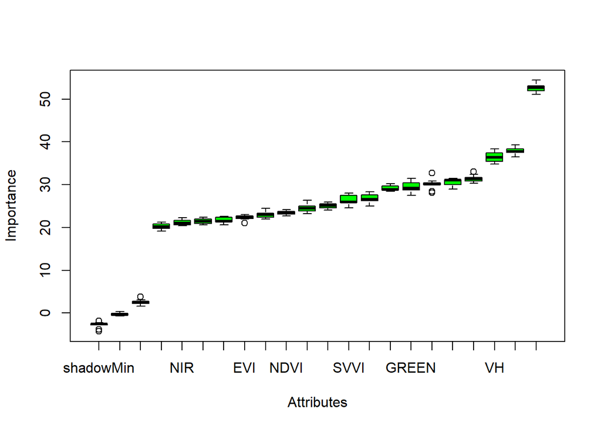

```r
plot(Var_sel_1)
```

Al correr el nombre del algoritmo, Var_sel_1, se obtiene un resumen general que evidencia que todas las variables fueron importantes en la modelacion. El plot del modelo Boruta (Var_sel_1) muestra en verde las variables que tienen mas importancia que las variables sombra, las cuales se muestran en azul. Era de esperar que todas los predictores contempladas en este analisis (Sentinel-1 y Sentinel-2) tengan incidencia en la clasificacion. Sin embargo, existen muchos ejemplos de articulos publicados de modelacion espacial donde el algoritmo Boruta excluye variables incrementando la exactitud tematica de los modelos (Kursa and Rudnicki 2010, Shi et al. 2019, Fagua et al. 2021).

NOTA: El profesor mostrara un ejemplo donde el algoritmo Boruta descarta variables sin efecto en la modelacion en este punto del tutorial.

Las siguientes lineas de codigo construyen un data.frame con los resultados del algoritmo Boruta seleccionando unicamente las variables que son confirmadas en el modelo (data.frame R2). Posteriormente se crea la TABLA_2, la cual es una segunda tabla despues de la eliminacion Boruta que queda lista para continuar con los ajustes de los parametros del modelo.

```r
R1 = attStats(Var_sel_1)
R1 = data.frame(rownames(R1),R1)
R1
```

```
##            rownames.R1.  meanImp medianImp   minImp   maxImp normHits  decision
## VV                   VV 30.56178  31.06772 28.98386 31.42047        1 Confirmed
## VH                   VH 36.48402  36.35621 34.80534 38.39950        1 Confirmed
## VHdivVV         VHdivVV 52.63372  52.69421 51.09410 54.40961        1 Confirmed
## VVminVH         VVminVH 30.11493  30.07496 28.11511 32.70113        1 Confirmed
## BLUE               BLUE 21.75946  21.48947 20.57969 22.59937        1 Confirmed
## GREEN             GREEN 29.53227  29.20127 27.46809 31.51776        1 Confirmed
## RED                 RED 26.83876  26.57698 24.94693 28.38203        1 Confirmed
## RED_EDGE_1   RED_EDGE_1 31.40923  31.38710 30.31588 33.05097        1 Confirmed
## RED_EDGE_2   RED_EDGE_2 20.24444  20.16575 19.12200 21.20208        1 Confirmed
## RED_EDGE_3   RED_EDGE_3 22.97513  22.98239 21.94618 24.51944        1 Confirmed
## NIR                 NIR 21.16819  20.97695 20.37858 22.27209        1 Confirmed
## RED_EDGE_4   RED_EDGE_4 25.05688  25.13644 24.08025 25.90577        1 Confirmed
## SWIR_1           SWIR_1 37.82263  37.70188 36.47596 39.31576        1 Confirmed
## SWIR_2           SWIR_2 29.21856  28.89529 28.44073 30.21411        1 Confirmed
## NDVI               NDVI 23.43221  23.31336 22.64702 24.16581        1 Confirmed
## EVI                 EVI 22.36015  22.51281 20.99617 22.98026        1 Confirmed
## SAVI               SAVI 21.43297  21.40981 20.55477 22.34107        1 Confirmed
## SVVI               SVVI 26.42306  25.97748 24.55815 27.99826        1 Confirmed
## RNDVI             RNDVI 24.55006  24.45563 23.19567 26.37319        1 Confirmed
```

```r
R2 = subset(R1, decision != "Rejected")
R2
```

```
##            rownames.R1.  meanImp medianImp   minImp   maxImp normHits  decision
## VV                   VV 30.56178  31.06772 28.98386 31.42047        1 Confirmed
## VH                   VH 36.48402  36.35621 34.80534 38.39950        1 Confirmed
## VHdivVV         VHdivVV 52.63372  52.69421 51.09410 54.40961        1 Confirmed
## VVminVH         VVminVH 30.11493  30.07496 28.11511 32.70113        1 Confirmed
## BLUE               BLUE 21.75946  21.48947 20.57969 22.59937        1 Confirmed
## GREEN             GREEN 29.53227  29.20127 27.46809 31.51776        1 Confirmed
## RED                 RED 26.83876  26.57698 24.94693 28.38203        1 Confirmed
## RED_EDGE_1   RED_EDGE_1 31.40923  31.38710 30.31588 33.05097        1 Confirmed
## RED_EDGE_2   RED_EDGE_2 20.24444  20.16575 19.12200 21.20208        1 Confirmed
## RED_EDGE_3   RED_EDGE_3 22.97513  22.98239 21.94618 24.51944        1 Confirmed
## NIR                 NIR 21.16819  20.97695 20.37858 22.27209        1 Confirmed
## RED_EDGE_4   RED_EDGE_4 25.05688  25.13644 24.08025 25.90577        1 Confirmed
## SWIR_1           SWIR_1 37.82263  37.70188 36.47596 39.31576        1 Confirmed
## SWIR_2           SWIR_2 29.21856  28.89529 28.44073 30.21411        1 Confirmed
## NDVI               NDVI 23.43221  23.31336 22.64702 24.16581        1 Confirmed
## EVI                 EVI 22.36015  22.51281 20.99617 22.98026        1 Confirmed
## SAVI               SAVI 21.43297  21.40981 20.55477 22.34107        1 Confirmed
## SVVI               SVVI 26.42306  25.97748 24.55815 27.99826        1 Confirmed
## RNDVI             RNDVI 24.55006  24.45563 23.19567 26.37319        1 Confirmed
```

```r
#
selected_vars = c("LeyEco", row.names(R2))
TABLA_2 = TABLA_1[,selected_vars]
str(TABLA_2)
```

```
## 'data.frame':    2456 obs. of  20 variables:
##  $ LeyEco    : Factor w/ 10 levels "1","2","3","4",..: 1 1 1 1 1 1 1 1 1 1 ...
##  $ VV        : int  1041 1901 2587 2029 1882 2256 2880 2560 2231 2544 ...
##  $ VH        : int  261 500 657 493 485 543 673 607 439 589 ...
##  $ VHdivVV   : int  3048 3085 3257 2663 2943 2822 2764 2680 2513 2936 ...
##  $ VVminVH   : int  780 1400 1930 1536 1397 1713 2206 1952 1791 1955 ...
##  $ BLUE      : int  370 370 320 312 364 338 290 316 309 336 ...
##  $ GREEN     : int  580 555 598 564 569 530 450 490 496 609 ...
##  $ RED       : int  379 408 307 301 331 316 307 289 279 321 ...
##  $ RED_EDGE_1: int  1016 902 994 961 821 847 812 823 805 978 ...
##  $ RED_EDGE_2: int  2375 2172 3181 2850 2489 2446 2309 2964 2602 2968 ...
##  $ RED_EDGE_3: int  2789 2646 3913 3558 3224 3084 2912 3727 3360 3704 ...
##  $ NIR       : int  2553 2691 4064 3386 3213 3143 2563 3496 3464 3733 ...
##  $ RED_EDGE_4: int  3149 2944 4214 3942 3551 3448 3271 4071 3728 3965 ...
##  $ SWIR_1    : int  1998 1986 1991 1853 1760 1791 1759 1912 1700 1838 ...
##  $ SWIR_2    : int  1019 1017 888 780 765 781 782 814 697 852 ...
##  $ NDVI      : int  7367 7303 8546 8359 8126 8151 7782 8433 8506 8362 ...
##  $ EVI       : int  4494 4614 6904 5991 5772 5639 4589 6208 6198 6456 ...
##  $ SAVI      : int  1807 1869 2644 2361 2242 2218 1893 2419 2422 2497 ...
##  $ SVVI      : int  198 176 19 39 27 52 119 56 -6 14 ...
##  $ RNDVI     : int  325 1056 1212 862 1283 1254 477 812 1414 1136 ...
```

## **4. AJUSTES DE LOS PARAMETROS DEL MODELO**

1. mtry: Este parametro es el numero de variables muestreadas aleatoriamente como candidatas en cada division o “Split” para cada arbol. El valor predeterminado para una clasificacion RF es sqrt(p) mientras que para una regresion es (p/3); donde p es el numero predictores. Se considera que este parametro es el que mas puede influir en la disminucion del error del modelo.
2. Numero de arboles: El numero de arboles se refiere al numero de re-muestreos independientes mediante Bootstrapping para generar arboles independientes de regresion o clasificacion. Este numero debe ser lo suficientemente grande para estabilizar el error; se considera que el error se estabiliza en aproximadamente 500 arboles. Sin embargo, si los datos no son tan grandes se aconseja usar 2000.
3. min node size: Este parametro especifica el numero minimo de observaciones en un nodo terminal (observaciones en la hoja final de cada arbol). Cuando existen muchos predictores “ruidosos” (este no es nuestro caso puesto que el analisis Boruta nos mostro que todos los predictores son importantes en el modelo), mayores tamanos de nodo optimizan la regresion o la clasificacion.
4. splitrule: La regla para hacer el Split. Para clasificacion y estimacion de probabilidad “gini”, “extraarboles” y “hellinger” son las opciones usadas. Para regresion “varianza”, “extraarboles”, “maxstat” y “beta”.
5. Sample fraction: Este parametro de tamano de muestra determina cuantas observaciones se extraen para el entrenamiento de cada arbol en cada Bootstrapping.

Antes de empezar el ajuste de los diferentes parametros, vamos a dividir los datos en dos: 1) Train o grupo de entrenamiento donde vamos a realizar la modelacion y que correspondera al 80% de los 2456 datos. 2) Test o grupo de prueba con el cual vamos a calcular errores una vez el mapa se construya y que correspondera al 20% de los 2456 datos. Para esto usamos la funcion createDataPartition().

```r
set.seed(3456)
trainIndex = createDataPartition(TABLA$LeyEco, p = .8,
                                 list = FALSE,
                                 times = 1)

#
head(trainIndex)
```

```
##      Resample1
## [1,]         2
## [2,]         3
## [3,]         4
## [4,]         5
## [5,]         6
## [6,]         7
```

```r
#
Train = TABLA[ trainIndex,]
dim(Train)
```

```
## [1] 1965   22
```

```r
names(Train)
```

```
##  [1] "LeyEco"     "Long"       "Lat"        "VV"         "VH"
##  [6] "VHdivVV"    "VVminVH"    "BLUE"       "GREEN"      "RED"
## [11] "RED_EDGE_1" "RED_EDGE_2" "RED_EDGE_3" "NIR"        "RED_EDGE_4"
## [16] "SWIR_1"     "SWIR_2"     "NDVI"       "EVI"        "SAVI"
## [21] "SVVI"       "RNDVI"
```

```r
Test  <- TABLA[-trainIndex,]
names(Test)
```

```
##  [1] "LeyEco"     "Long"       "Lat"        "VV"         "VH"
##  [6] "VHdivVV"    "VVminVH"    "BLUE"       "GREEN"      "RED"
## [11] "RED_EDGE_1" "RED_EDGE_2" "RED_EDGE_3" "NIR"        "RED_EDGE_4"
## [16] "SWIR_1"     "SWIR_2"     "NDVI"       "EVI"        "SAVI"
## [21] "SVVI"       "RNDVI"
```

Ahora fijaremos el numero de variables predictoras para lo cual creamos k1, con k1 no necesitaras contar las variables predictoras ni cambiar este numero manualmente en el modelamiento. Despues creamos una lista (control) usando la funcion trainControl(),t donde queda especificado que vamos a correr validaciones cruzadas (method=‘repeatedcv’), de 10 grupos (number=10), y repetiremos esto 2 veces (repeats=2).

```r
#Numero de variables predictoras
k1=ncol(TABLA_1)-1

#Ordenes de control
control = trainControl(method='repeatedcv',
                        number=10,
                        repeats=2)
```

Despues creamos unos vectores mtry_2, min.node.size_2, splitrule_2 que especificaran la variacion de los parametros a probar. Posteriormente creamos un data.frame con la funcion expand.grid() que contendra estos vectores.

```r
mtry_2 = c(2,3,sqrt(k1),5,6,7,8,9,10)
min.node.size_2 = c(1, 3, 5, 10)
splitrule_2 = c('gini','extratrees')

tunegrid_1 <- expand.grid(mtry=mtry_2)

tunegrid_2 <- expand.grid(mtry=mtry_2,
                          min.node.size=min.node.size_2,
                          splitrule=splitrule_2)
```

Hacemos dos tipos de ajuste: 1) el primero teniendo en cuenta la variacion de mtry empleando la libreria randomForest (rf_1); este analisis dura 10 minutos aproximadamente. 2) el segundo teniendo en cuenta la variacion de mtry, min.node.size, y splitruleb(rf_2); este analisis dura 20 minutos aproximadamente. Debido al tiempo de procesamiento no correremos rf_2, pero ustedes pueden abrir un archivo .csv con los resultados de este analisis (RESULTADO_rf1.csv y RESULTADO_rf2.csv).

```r
Train$LeyEco = as.factor(Train$LeyEco)

rf_1 <- train(LeyEco~.,
              data=Train[,c(1,4:22)],
              method='rf',
              metric= 'Accuracy',
              tuneGrid=tunegrid_1,
              trControl=control)

print(rf_1)
```

```
## Random Forest
##
## 1965 samples
##   19 predictor
##   10 classes: '1', '2', '3', '4', '5', '7', '8', '9', '10', '11'
##
## No pre-processing
## Resampling: Cross-Validated (10 fold, repeated 2 times)
## Summary of sample sizes: 1769, 1769, 1767, 1767, 1769, 1770, ...
## Resampling results across tuning parameters:
##
##   mtry       Accuracy   Kappa
##    2.000000  0.8048252  0.7780143
##    3.000000  0.8068660  0.7803501
##    4.582576  0.8043291  0.7774861
##    5.000000  0.8025524  0.7754593
##    6.000000  0.8038266  0.7769352
##    7.000000  0.8063610  0.7798014
##    8.000000  0.8022960  0.7751720
##    9.000000  0.8005077  0.7731443
##   10.000000  0.8012846  0.7740544
##
## Accuracy was used to select the optimal model using the largest value.
## The final value used for the model was mtry = 3.
```

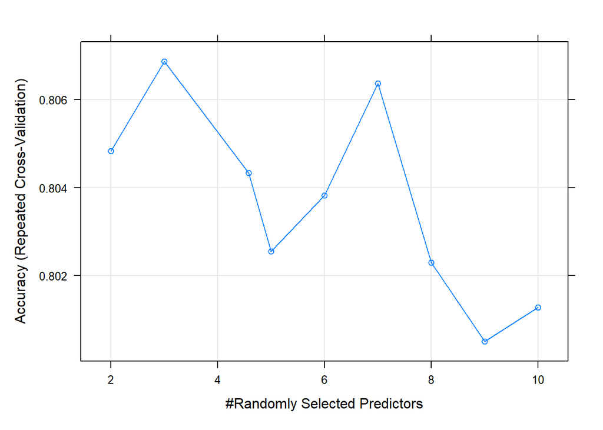

```r
plot(rf_1)
```

```r
#

#rf_2 <- train(LeyEco~.,
              #data=Train,
              #method='ranger',
              #metric='Agccuracy',
              #tuneGrid=tunegrid_2,
              #trControl=control)

#print(rf_2)
#plot(rf_2)
```

## **5. MODELACION ESPACIAL**

Para generar el modelo espacial o mapa tenemos que predecir el mejor modelo en los raster de las variables Sentinel-1 y Sentinel-2 empleando la tabla de datos Train, la cual relaciona la interpretacion visual con las variables Sentinel. Lo primero que hacemos es leer los raster usando la funcion brick() para despues integrar ambos raster en un solo raster usando la funcion stack(). Observe los nombres de las bandas resultantes.

```r
Sent_1 = brick("Sent1_mean_2020_small_limit.tif")
Sent_2 = brick("Sent2_mean_2020_small_limit.tif ")

RASTER.PREDICTORS = stack(Sent_1, Sent_2)

names(RASTER.PREDICTORS)
```

```
##  [1] "Sent1_mean_2020_small_limit.1"  "Sent1_mean_2020_small_limit.2"
##  [3] "Sent1_mean_2020_small_limit.3"  "Sent1_mean_2020_small_limit.4"
##  [5] "Sent2_mean_2020_small_limit.1"  "Sent2_mean_2020_small_limit.2"
##  [7] "Sent2_mean_2020_small_limit.3"  "Sent2_mean_2020_small_limit.4"
##  [9] "Sent2_mean_2020_small_limit.5"  "Sent2_mean_2020_small_limit.6"
## [11] "Sent2_mean_2020_small_limit.7"  "Sent2_mean_2020_small_limit.8"
## [13] "Sent2_mean_2020_small_limit.9"  "Sent2_mean_2020_small_limit.10"
## [15] "Sent2_mean_2020_small_limit.11" "Sent2_mean_2020_small_limit.12"
## [17] "Sent2_mean_2020_small_limit.13" "Sent2_mean_2020_small_limit.14"
## [19] "Sent2_mean_2020_small_limit.15"
```

Ahora remplazamos los nombres de la data.frame Train con los nombres de RASTER.PREDICTORS. Esto se hace porque para correr la modelacion espacial, los nombres del raster de las variables predictoras deben coincidir con los nombres del data.frame Train. Finalmente corremos el modelo y usamos la funcion predict() para predecir el modelo en el raster de los predictores y obtener el mapa. Puedes plotear el mapa y exportarlo.

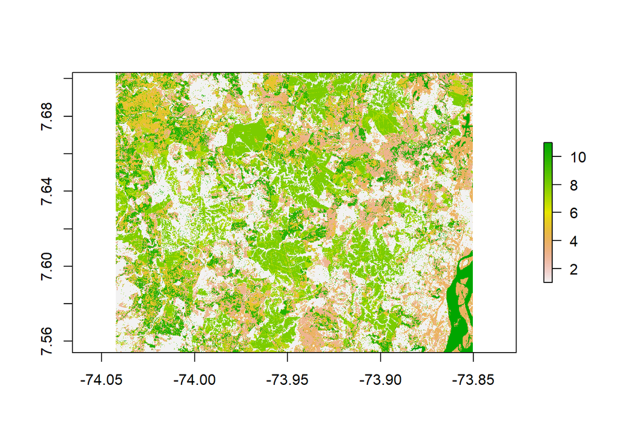

```r
Train_2 = Train[,c(1,4:22)]

names1= c(names(RASTER.PREDICTORS))
names(Train_2) = c("LeyEco",names1)

RANGER.REGRE = randomForest(LeyEco~., data=Train_2, ntree = 500,
                     mtry = 9, nodesize = 3)


RANGER.MAPA = predict(RASTER.PREDICTORS,RANGER.REGRE)
plot(RANGER.MAPA)
```

```r
#writeRaster(RANGER.MAPA, filename = "MAPA_LeyEco.tif", format = "GTiff")
```

Ahora, vamos a estimar los errores del mapa (exactitud tematica) empleando el grupo de datos Test, el cual no ha sido utilizado en la modelacion. Las siguientes lineas de codigo abren el mapa que generamos y extraen las coberturas de tierra del mapa (valores estimados) para estimar accuracy y kappa por comparacion con los valores reales definidos por los interpretes.

```r
IMG_MAPA = raster("MAPA_LeyEco.tif")
#
point.to.extract = SpatialPointsDataFrame(coords = Test[,c("Long","Lat")], data = Test,
                                          proj4string = CRS("+proj=longlat +datum=WGS84 +no_defs +ellps=WGS84 +towgs84=0,0,0"))
#
extraction.table =extract(IMG_MAPA, point.to.extract)
TABLA_2 = data.frame(extraction.table,point.to.extract)
names(TABLA_2)
```

```
##  [1] "extraction.table" "LeyEco"           "Long"             "Lat"
##  [5] "VV"               "VH"               "VHdivVV"          "VVminVH"
##  [9] "BLUE"             "GREEN"            "RED"              "RED_EDGE_1"
## [13] "RED_EDGE_2"       "RED_EDGE_3"       "NIR"              "RED_EDGE_4"
## [17] "SWIR_1"           "SWIR_2"           "NDVI"             "EVI"
## [21] "SAVI"             "SVVI"             "RNDVI"            "Long.1"
## [25] "Lat.1"            "optional"
```

```r
head(TABLA_2)
```

```
##    extraction.table LeyEco      Long      Lat   VV  VH VHdivVV VVminVH BLUE
## 1                 1      1 -73.85701 7.625664 1041 261    3048     780  370
## 9                 1      1 -73.98835 7.624496 2231 439    2513    1791  309
## 10                1      1 -73.87417 7.658991 2544 589    2936    1955  336
## 12                1      1 -73.98646 7.666357 1931 439    2722    1492  272
## 21                1      1 -73.88450 7.649110 3082 672    2790    2410  333
## 22                1      1 -73.92367 7.642552 2311 487    2530    1823  327
##    GREEN RED RED_EDGE_1 RED_EDGE_2 RED_EDGE_3  NIR RED_EDGE_4 SWIR_1 SWIR_2
## 1    580 379       1016       2375       2789 2553       3149   1998   1019
## 9    496 279        805       2602       3360 3464       3728   1700    697
## 10   609 321        978       2968       3704 3733       3965   1838    852
## 12   391 245        645       2023       2668 2352       2999   1414    592
## 21   600 320        940       3230       4022 3988       4374   2024    896
## 22   545 307        812       2610       3397 3444       3764   1718    719
##    NDVI  EVI SAVI SVVI RNDVI    Long.1    Lat.1 optional
## 1  7367 4494 1807  198   325 -73.85701 7.625664     TRUE
## 9  8506 6198 2422   -6  1414 -73.98835 7.624496     TRUE
## 10 8362 6456 2497   14  1136 -73.87417 7.658991     TRUE
## 12 8089 4458 1837   49   738 -73.98646 7.666357     TRUE
## 21 8459 6803 2605   31  1034 -73.88450 7.649110     TRUE
## 22 8348 6094 2379   -5  1402 -73.92367 7.642552     TRUE
```

```r
ACU = accuracy(actual = TABLA_2$LeyEco, predicted = TABLA_2$extraction.table)
ACU
```

```
## [1] 0.7983707
```

```r
KAP = kappa2(TABLA_2[,1:2])
KAP
```

```
##  Cohen's Kappa for 2 Raters (Weights: unweighted)
##
##  Subjects = 491
##    Raters = 2
##     Kappa = 0.771
##
##         z = 46.3
##   p-value = 0
```

Para calcular los detalles de la matriz de confusion podemos remplazar los numeros por los nombres de la coberturas primero en LeyEco

```r
table(TABLA_2$LeyEco)
```

```
##
##  1  2  3  4  5  7  8  9 10 11
## 59  8 59 62 58 58 63  4 62 58
```

```r
TABLA_2$LeyEco[TABLA_2$LeyEco == 1] = "BOSQUE"
TABLA_2$LeyEco[TABLA_2$LeyEco == 2] = "ARBUSTO"
TABLA_2$LeyEco[TABLA_2$LeyEco == 3] = "HERBACEO"
TABLA_2$LeyEco[TABLA_2$LeyEco == 4] = "HUMEDALES"
TABLA_2$LeyEco[TABLA_2$LeyEco == 5] = "PASTO"
TABLA_2$LeyEco[TABLA_2$LeyEco == 6] = "CULTIVO"
TABLA_2$LeyEco[TABLA_2$LeyEco == 7] = "PALMA_JOVEN"
TABLA_2$LeyEco[TABLA_2$LeyEco == 8] = "PALMA_MADURA"
TABLA_2$LeyEco[TABLA_2$LeyEco == 9] = "INFRAES"
TABLA_2$LeyEco[TABLA_2$LeyEco == 10] = "SUELO"
TABLA_2$LeyEco[TABLA_2$LeyEco == 11] = "AGUA"

table(TABLA_2$LeyEco)
```

```
##
##         AGUA      ARBUSTO       BOSQUE     HERBACEO    HUMEDALES      INFRAES
##           58            8           59           59           62            4
##  PALMA_JOVEN PALMA_MADURA        PASTO        SUELO
##           58           63           58           62
```

Segundo hacemos el remplazo de nombres en extraction.table

```r
table(TABLA_2$extraction.table)
```

```
##
##  1  2  3  4  5  7  8  9 10 11
## 69  3 69 49 68 68 52  2 53 58
```

```r
TABLA_2$extraction.table[TABLA_2$extraction.table == 1] = "BOSQUE"
TABLA_2$extraction.table[TABLA_2$extraction.table == 2] = "ARBUSTO"
TABLA_2$extraction.table[TABLA_2$extraction.table == 3] = "HERBACEO"
TABLA_2$extraction.table[TABLA_2$extraction.table == 4] = "HUMEDALES"
TABLA_2$extraction.table[TABLA_2$extraction.table == 5] = "PASTO"
TABLA_2$extraction.table[TABLA_2$extraction.table == 6] = "CULTIVO"
TABLA_2$extraction.table[TABLA_2$extraction.table == 7] = "PALMA_JOVEN"
TABLA_2$extraction.table[TABLA_2$extraction.table == 8] = "PALMA_MADURA"
TABLA_2$extraction.table[TABLA_2$extraction.table == 9] = "INFRAES"
TABLA_2$extraction.table[TABLA_2$extraction.table == 10] = "SUELO"
TABLA_2$extraction.table[TABLA_2$extraction.table == 11] = "AGUA"

table(TABLA_2$extraction.table)
```

```
##
##         AGUA      ARBUSTO       BOSQUE     HERBACEO    HUMEDALES      INFRAES
##           58            3           69           69           49            2
##  PALMA_JOVEN PALMA_MADURA        PASTO        SUELO
##           68           52           68           53
```

Ahora volvemos a calcular la tabla que muestra la matriz de confusion.

```r
Matriz_C <- table(TABLA_2$extraction.table,TABLA_2$LeyEco)
Matriz_C
```

```
##
##                AGUA ARBUSTO BOSQUE HERBACEO HUMEDALES INFRAES PALMA_JOVEN
##   AGUA           56       0      0        0         2       0           0
##   ARBUSTO         0       2      0        0         0       0           1
##   BOSQUE          0       3     54        0         3       0           1
##   HERBACEO        0       2      1       49         6       0           0
##   HUMEDALES       1       1      2        1        44       0           0
##   INFRAES         0       0      0        0         0       2           0
##   PALMA_JOVEN     0       0      1        0         1       1          50
##   PALMA_MADURA    0       0      1        0         2       0           2
##   PASTO           0       0      0        5         2       0           2
##   SUELO           1       0      0        4         2       1           2
##
##                PALMA_MADURA PASTO SUELO
##   AGUA                    0     0     0
##   ARBUSTO                 0     0     0
##   BOSQUE                  5     0     3
##   HERBACEO                0     2     9
##   HUMEDALES               0     0     0
##   INFRAES                 0     0     0
##   PALMA_JOVEN            11     1     3
##   PALMA_MADURA           47     0     0
##   PASTO                   0    50     9
##   SUELO                   0     5    38
```

```r
ACU = accuracy(actual = TABLA_2$LeyEco, predicted = TABLA_2$extraction.table)
ACU
```

```
## [1] 0.7983707
```

```r
KAP = kappa2(TABLA_2[,1:2])
KAP
```

```
##  Cohen's Kappa for 2 Raters (Weights: unweighted)
##
##  Subjects = 491
##    Raters = 2
##     Kappa = 0.771
##
##         z = 46.3
##   p-value = 0
```

Finalmente estimamos los detalles de la matriz de confusion.

```r
MC = table(TABLA_2$LeyEco,
           TABLA_2$extraction.table, dnn = c("Cober_Predecida","Cober_Observada"))
str(MC)
```

```
##  'table' int [1:10, 1:10] 56 0 0 0 2 0 0 0 0 0 ...
##  - attr(*, "dimnames")=List of 2
##   ..$ Cober_Predecida: chr [1:10] "AGUA" "ARBUSTO" "BOSQUE" "HERBACEO" ...
##   ..$ Cober_Observada: chr [1:10] "AGUA" "ARBUSTO" "BOSQUE" "HERBACEO" ...
```

```r
confusionMatrix(MC)
```

```
## Confusion Matrix and Statistics
##
##                Cober_Observada
## Cober_Predecida AGUA ARBUSTO BOSQUE HERBACEO HUMEDALES INFRAES PALMA_JOVEN
##    AGUA           56       0      0        0         1       0           0
##    ARBUSTO         0       2      3        2         1       0           0
##    BOSQUE          0       0     54        1         2       0           1
##    HERBACEO        0       0      0       49         1       0           0
##    HUMEDALES       2       0      3        6        44       0           1
##    INFRAES         0       0      0        0         0       2           1
##    PALMA_JOVEN     0       1      1        0         0       0          50
##    PALMA_MADURA    0       0      5        0         0       0          11
##    PASTO           0       0      0        2         0       0           1
##    SUELO           0       0      3        9         0       0           3
##                Cober_Observada
## Cober_Predecida PALMA_MADURA PASTO SUELO
##    AGUA                    0     0     1
##    ARBUSTO                 0     0     0
##    BOSQUE                  1     0     0
##    HERBACEO                0     5     4
##    HUMEDALES               2     2     2
##    INFRAES                 0     0     1
##    PALMA_JOVEN             2     2     2
##    PALMA_MADURA           47     0     0
##    PASTO                   0    50     5
##    SUELO                   0     9    38
##
## Overall Statistics
##
##                Accuracy : 0.7984
##                  95% CI : (0.7601, 0.833)
##     No Information Rate : 0.1405
##     P-Value [Acc > NIR] : < 2.2e-16
##
##                   Kappa : 0.7708
##
##  Mcnemar's Test P-Value : NA
##
## Statistics by Class:
##
```

[output cut: 12 more lines]

```
## Pos Pred Value                0.70968       0.500000             0.8621
## Neg Pred Value                0.98834       1.000000             0.9584
## Prevalence                    0.09980       0.004073             0.1385
## Detection Rate                0.08961       0.004073             0.1018
## Detection Prevalence          0.12627       0.008147             0.1181
## Balanced Accuracy             0.92862       0.997955             0.8582
##                      Class: PALMA_MADURA Class: PASTO Class: SUELO
## Sensitivity                      0.90385       0.7353      0.71698
## Specificity                      0.96355       0.9811      0.94521
## Pos Pred Value                   0.74603       0.8621      0.61290
## Neg Pred Value                   0.98832       0.9584      0.96503
## Prevalence                       0.10591       0.1385      0.10794
## Detection Rate                   0.09572       0.1018      0.07739
## Detection Prevalence             0.12831       0.1181      0.12627
## Balanced Accuracy                0.93370       0.8582      0.83109
```

## **Literatura citada**

Fagua, J. C., P. Jantz, P. Burns, R. Massey, J. Y. Buitrago, S. Saatchi, C. Hakkenberg, and S. J. Goetz. 2021. Mapping tree diversity in the tropical forest region of Choco-Colombia. Environmental Research Letters 16:54024.

Kursa, M. B., and W. R. Rudnicki. 2010. Feature Selection with the Boruta Package. JOURNAL OF STATISTICAL SOFTWARE 36:1-13.

Lansley, G., and J. Cheshire. 2016. An Introduction to Spatial Data Analysis and Visualisation in R. University College London, London, UK.

R Core Team, R. project. 2021. An Introduction to R.

https://cran.r-project.org/doc/manuals/r-release/R-intro.html#Introduction-and-preliminaries. Shi, L., J. A. Westerhuis, J. Rosen, R. Landberg, and C. Brunius. 2019. Variable selection and validation in multivariate modelling. BIOINFORMATICS 35:972-980.